# Generalized Linear Mixed Effects Models

## Varying Intercepts

Based on the plot, we have some big departmental differences. Let’s specify department as a random effect in the model.

$n_{admit,ij} \sim \text{Binomial}(n_{ij},p_{ij})~~~$ $\text{logit}(p_{ij})=\alpha_{0i}+\beta\text{male}_{j}$ $\alpha_{0i} \sim N(\alpha,\sigma) ~~~ \sigma \sim \text{HalfCauchy}(0,1)$ $\alpha \sim N(0,3^2)$ and $\beta \sim N(0,1)$

```r
adm2 <-
  brm(data = d, family = binomial,
      admit | trials(applications) ~ 1 + male + (1 | dept_id),
      prior = c(prior(normal(0, 3), class = Intercept),
                prior(normal(0, 1), class = b),
                prior(cauchy(0, 1), class = sd)),
      iter = 4500, warmup = 500, chains = 3, cores = 3,
      seed = 13,
      control = list(adapt_delta = 0.99))
```

```
## Inference for Stan model: cfc03ce4b5376496b22da527429eff69.
## 3 chains, each with iter=4500; warmup=500; thin=1;
## post-warmup draws per chain=4000, total post-warmup draws=12000.
##
##                          mean se_mean   sd   2.5%    25%    50%    75%  97.5%
## b_Intercept             -0.58    0.01 0.58  -1.74  -0.92  -0.57  -0.23   0.60
## b_male                  -0.09    0.00 0.08  -0.25  -0.15  -0.09  -0.04   0.06
## sd_dept_id__Intercept    1.36    0.01 0.49   0.75   1.04   1.25   1.56   2.62
## r_dept_id[1,Intercept]   1.25    0.01 0.58   0.08   0.91   1.24   1.59   2.43
## r_dept_id[2,Intercept]   1.20    0.01 0.58   0.02   0.86   1.20   1.55   2.38
## r_dept_id[3,Intercept]  -0.01    0.01 0.58  -1.18  -0.35  -0.02   0.34   1.17
## r_dept_id[4,Intercept]  -0.04    0.01 0.58  -1.22  -0.39  -0.05   0.30   1.13
## r_dept_id[5,Intercept]  -0.48    0.01 0.58  -1.68  -0.83  -0.49  -0.14   0.68
## r_dept_id[6,Intercept]  -2.03    0.01 0.59  -3.23  -2.38  -2.03  -1.68  -0.86
## lp__                   -60.93    0.05 2.53 -66.96 -62.41 -60.57 -59.08 -57.07
##                        n_eff Rhat
## b_Intercept             1973    1
## b_male                  4652    1
## sd_dept_id__Intercept   2071    1
## r_dept_id[1,Intercept]  1983    1
## r_dept_id[2,Intercept]  1994    1
## r_dept_id[3,Intercept]  1977    1
## r_dept_id[4,Intercept]  1980    1
## r_dept_id[5,Intercept]  1999    1
## r_dept_id[6,Intercept]  2053    1
## lp__                    2404    1
##
## Samples were drawn using NUTS(diag_e) at Mon Oct  5 08:26:05 2020.
## For each parameter, n_eff is a crude measure of effective sample size,
## and Rhat is the potential scale reduction factor on split chains (at
## convergence, Rhat=1).
```

In this model we see no evidence of a difference in admissions probabilities by gender though we do see big departmental variability.

Let’s evaluate whether we need a random effect for gender.

```r
adm3 <-
  brm(data = d, family = binomial,
      admit | trials(applications) ~ 1 + male + (1 + male | dept_id),
      prior = c(prior(normal(0, 3), class = Intercept),
                prior(normal(0, 1), class = b),
                prior(cauchy(0, 1), class = sd),
                prior(lkj(2), class = cor)),
      iter = 5000, warmup = 1000, chains = 4, cores = 4,
      seed = 13,
      control = list(adapt_delta = .99,
                     max_treedepth = 12))
adm3$fit
```

```
## Inference for Stan model: 2c08311663aa21c2a5d74151615de975.
## 4 chains, each with iter=5000; warmup=1000; thin=1;
## post-warmup draws per chain=4000, total post-warmup draws=16000.
##
##                                mean se_mean   sd   2.5%    25%    50%    75%
## b_Intercept                   -0.49    0.01 0.66  -1.81  -0.88  -0.49  -0.10
## b_male                        -0.16    0.00 0.22  -0.61  -0.29  -0.15  -0.03
## sd_dept_id__Intercept          1.55    0.01 0.57   0.85   1.18   1.43   1.77
## sd_dept_id__male               0.46    0.00 0.23   0.14   0.31   0.42   0.56
## cor_dept_id__Intercept__male  -0.32    0.00 0.34  -0.86  -0.58  -0.36  -0.09
## r_dept_id[1,Intercept]         1.77    0.01 0.69   0.41   1.35   1.77   2.19
## r_dept_id[2,Intercept]         1.22    0.01 0.71  -0.17   0.78   1.22   1.65
## r_dept_id[3,Intercept]        -0.16    0.01 0.66  -1.48  -0.55  -0.15   0.23
## r_dept_id[4,Intercept]        -0.13    0.01 0.66  -1.44  -0.53  -0.12   0.26
## r_dept_id[5,Intercept]        -0.64    0.01 0.67  -1.96  -1.04  -0.63  -0.24
## r_dept_id[6,Intercept]        -2.11    0.01 0.68  -3.47  -2.52  -2.10  -1.70
## r_dept_id[1,male]             -0.61    0.00 0.31  -1.29  -0.80  -0.59  -0.40
## r_dept_id[2,male]             -0.04    0.00 0.34  -0.72  -0.25  -0.04   0.16
## r_dept_id[3,male]              0.24    0.00 0.25  -0.22   0.08   0.22   0.39
## r_dept_id[4,male]              0.07    0.00 0.24  -0.42  -0.08   0.06   0.21
## r_dept_id[5,male]              0.27    0.00 0.27  -0.22   0.10   0.26   0.44
## r_dept_id[6,male]              0.04    0.00 0.31  -0.57  -0.15   0.04   0.23
## lp__                         -65.40    0.06 3.75 -73.93 -67.62 -64.97 -62.75
##                               97.5% n_eff Rhat
## b_Intercept                    0.83  3945    1
## b_male                         0.28  6930    1
## sd_dept_id__Intercept          2.95  4826    1
## sd_dept_id__male               1.03  5744    1
## cor_dept_id__Intercept__male   0.43 11185    1
## r_dept_id[1,Intercept]         3.16  4189    1
## r_dept_id[2,Intercept]         2.63  4555    1
## r_dept_id[3,Intercept]         1.17  3976    1
## r_dept_id[4,Intercept]         1.21  3980    1
## r_dept_id[5,Intercept]         0.69  3999    1
## r_dept_id[6,Intercept]        -0.76  4182    1
## r_dept_id[1,male]             -0.06  8219    1
## r_dept_id[2,male]              0.64 12811    1
## r_dept_id[3,male]              0.76  7727    1
## r_dept_id[4,male]              0.57  7666    1
## r_dept_id[5,male]              0.84  8835    1
## r_dept_id[6,male]              0.64 11681    1
## lp__                         -59.32  3360    1
##
## Samples were drawn using NUTS(diag_e) at Mon Oct  5 08:37:59 2020.
## For each parameter, n_eff is a crude measure of effective sample size,
## and Rhat is the potential scale reduction factor on split chains (at
## convergence, Rhat=1).
```

Before we get too excited let’s look at some diagnostics.

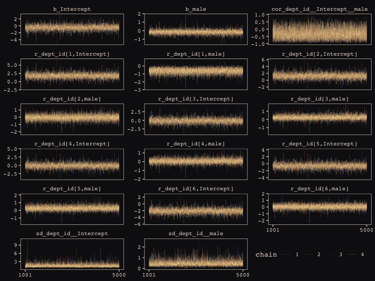

```r
post <- posterior_samples(adm3, add_chain = T)

post %>%
  select(-lp__) %>%
  gather(key, value, -chain, -iter) %>%
  mutate(chain = as.character(chain)) %>%

  ggplot(aes(x = iter, y = value, group = chain, color = chain)) +
  geom_line(size = 1/15) +
  scale_color_manual(values = c("#80A0C7", "#B1934A", "#A65141", "#EEDA9D")) +
  scale_x_continuous(NULL, breaks = c(1001, 5000)) +
  ylab(NULL) +
  theme_pearl_earring +
  theme(legend.position  = c(.825, .06),
        legend.direction = "horizontal") +
  facet_wrap(~key, ncol = 3, scales = "free_y")
```

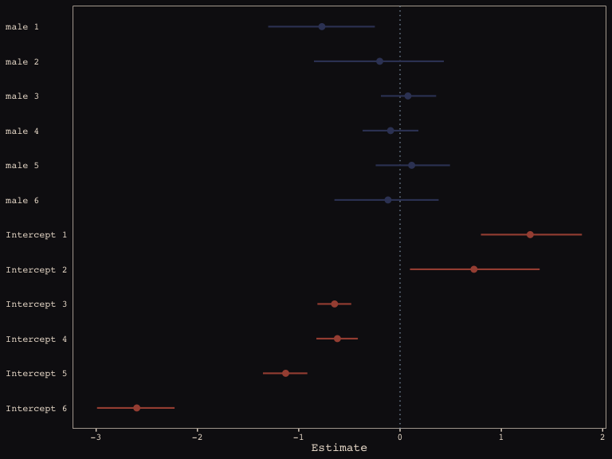

```r
rbind(coef(adm3)$dept_id[, , 1],
      coef(adm3)$dept_id[, , 2]) %>%
  as_tibble() %>%
  mutate(param   = c(paste("Intercept", 1:6), paste("male", 1:6)),
         reorder = c(6:1, 12:7)) %>%

  # plot
  ggplot(aes(x = reorder(param, reorder))) +
  geom_hline(yintercept = 0, linetype = 3, color = "#8B9DAF") +
  geom_pointrange(aes(ymin = Q2.5, ymax = Q97.5, y = Estimate, color = reorder < 7),
                  shape = 20, size = 3/4) +
  scale_color_manual(values = c("#394165", "#A65141")) +
  xlab(NULL) +
  coord_flip() +
  theme_pearl_earring +
  theme(legend.position = "none",
        axis.ticks.y    = element_blank(),
        axis.text.y     = element_text(hjust = 0))
```

We see much more variability in the random intercepts than in the random slopes.

## What happened at Berkeley?

What happened at Berkeley? It actually doesn’t require too much sophisticated modeling. What we’re seeing is Simpson’s paradox.

```r
d[,c(1,2,3,4,8)]
```

```
##    dept applicant.gender admit reject successrate
## 1     A             male   512    313  0.62060606
## 2     A           female    89     19  0.82407407
## 3     B             male   353    207  0.63035714
## 4     B           female    17      8  0.68000000
## 5     C             male   120    205  0.36923077
## 6     C           female   202    391  0.34064081
## 7     D             male   138    279  0.33093525
## 8     D           female   131    244  0.34933333
## 9     E             male    53    138  0.27748691
## 10    E           female    94    299  0.23918575
## 11    F             male    22    351  0.05898123
## 12    F           female    24    317  0.07038123
```

In the raw data, women had higher acceptance probabilities in 4 of the 6 departments. However, the departments to which they applied in higher numbers were the departments that had lower overall acceptance rates.

What happened is that women were more likely to apply do departments like English, which have trouble supporting grad students, and they were less likely to apply to STEM departments, which had more plentiful funding for graduate students. The men, on the other hand, were much more likely to apply to the STEM departments that had higher acceptance rates.